# Assignment 6

### `pmax`

#### April D. Makukhov

The ‘p’ in pmax stands for ‘parallel’. This function outputs the parallel maxima of values inputed. Essentially, this means you can take one or more vectors and, with pmax, create a single vector that has only the maxima between the multiple vectors. pmax allows you to find the maximum values among multiple vectors and receive an output with those maximum values.

```r
# Making 2 vectors, x and y, of the same length
x <- c(1,5,7,9,3,15,37,128,4)
y <- c(2,8,12,54,207,95,73,122,62)
pmax(x,y) # this gives a single output vector that contains the maximum values of these two vectors with respect to position. For example, the first value of the pmax vector is 2 because '2' in the first position of vector y is greater than '1' in the first position of vector x.
```

```
## [1]   2   8  12  54 207  95  73 128  62
```

### `list`

#### April D. Makukhov

This function is used to create a list in R, which can be made up of numeric values or even variable names.

```r
y<-list(1,2,3,4)
y
```

```
## [[1]]
## [1] 1
##
## [[2]]
## [1] 2
##
## [[3]]
## [1] 3
##
## [[4]]
## [1] 4
```

```r
x<-list('apple','orange','strawberry','kiwi')
x
```

```
## [[1]]
## [1] "apple"
##
## [[2]]
## [1] "orange"
##
## [[3]]
## [1] "strawberry"
##
## [[4]]
## [1] "kiwi"
```

```r
z<- c(x,y) # here is an example where I am combining the 2 lists I made above into one vector

z
```

```
## [[1]]
## [1] "apple"
##
## [[2]]
## [1] "orange"
##
## [[3]]
## [1] "strawberry"
##
## [[4]]
## [1] "kiwi"
##
## [[5]]
## [1] 1
##
## [[6]]
## [1] 2
##
## [[7]]
## [1] 3
##
## [[8]]
## [1] 4
```

```r
# list is also a useful function for plotting. In this example below, we are using data that is already in R (car data), and creating a vector z that is making a list made up of components 'x' and 'y', and each of those components is equal to a column of data from the cars dataset.

z <-list(x=cars[,1], y=cars[,2]) # making a list with 2 components, x and y, where x is comprised of the cars data in column 1 of the dataset, and y is comprised of the cars data in column 2 of the dataset

z
```

```
## $x
##  [1]  4  4  7  7  8  9 10 10 10 11 11 12 12 12 12 13 13 13 13 14 14 14 14
## [24] 15 15 15 16 16 17 17 17 18 18 18 18 19 19 19 20 20 20 20 20 22 23 24
## [47] 24 24 24 25
##
## $y
##  [1]   2  10   4  22  16  10  18  26  34  17  28  14  20  24  28  26  34
## [18]  34  46  26  36  60  80  20  26  54  32  40  32  40  50  42  56  76
## [35]  84  36  46  68  32  48  52  56  64  66  54  70  92  93 120  85
```

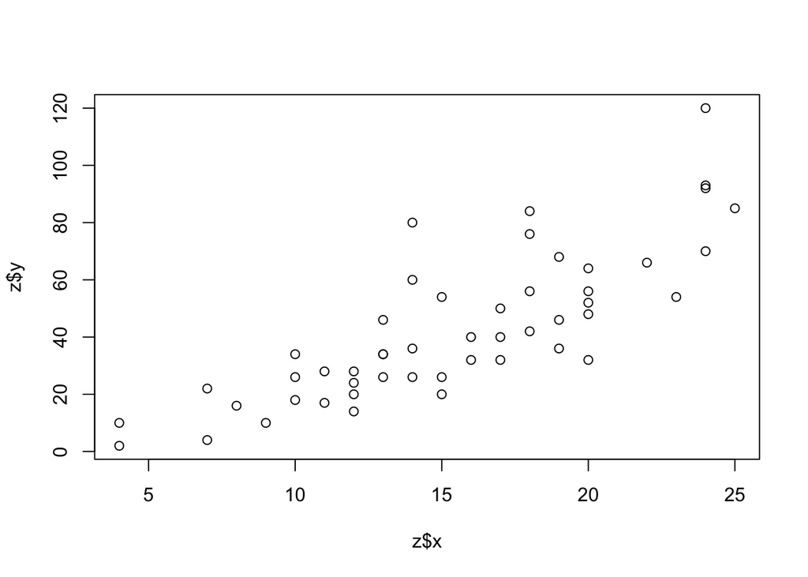

```r
plot(z) # after creating this vector z, we can see the 2 components of the list, z$x and z$y, plotted against each other
```